# 20230726_missNetFunctions

2023-11-24

## Setting up preamble

```r
# packages
library(here)
library(ergm)
library(sna)
library(network)
library(testthat)

#### sorting out the datasets I want to be using
### They are all undirected.
## Jemaah Islamiyah
# has 11 time slices for a lot of these datasets, so I'm taking out specific years (~randomly chosen)
# this set is the Bali bombing dataset 2002 during 2002 (i.e., looks dense.)
baliBombing2002 = as.matrix(read.csv(file = here("Data", "BaliBombing2002", "BALIBOMBING2002_2002.csv"), header = T, row.names = "X"))

# this one is the Bali bombing dataset 2005 during 2005 (not sure what the 2 index is)
baliBombing2005 = as.matrix(read.csv(file = here("Data", "BaliBombing2005", "BALIBOMBING2005_2005_2.csv"), header = T, row.names = "X"))

# Christmas eve bombing 2000 during 2000
xmasBombing2000 = as.matrix(read.csv(file = here("Data", "ChristmasEveBombing2000", "CHRISTMASEVEINDONESIA_2000.csv"), header = T, row.names = "X"))

# Aus embassy bombing 2004 during 2004
ausBombing2004 = as.matrix(read.csv(file = here("Data", "AustralianEmbassyBombing", "AE_INDO_2004.csv"), header = T, row.names = "X"))

## Hamburg cell
# not sure what the 2 index is either
hamburgCell2001 = as.matrix(read.csv(file = here("Data", "HamburgCell", "HAMBURG_2001_2.csv"), header = T, row.names = "X"))

## London Gangs 2005-2009
# also comes with attributes
londonGangs = as.matrix(read.csv(file = here("Data", "LondonGangs", "LONDON_GANG.csv"), header = T, row.names = "X"))
londonGangsAtt = read.csv(file = here("Data", "LondonGangs", "LONDON_GANG_ATTR.csv"), row.names = "X")

#### Tie definitions
## All the Jemaah Islamiyah networks have the same tie definitions
# 0 = no relation
# 1 = Acquaintance/distant family (limited to radical organisational activity)
# 2 = Friends/moderately close family
# 3 = Close family/friends

# so let's binarise
# Bali bombing 2002
bali2002AdjMat = baliBombing2002
bali2002AdjMat[bali2002AdjMat > 0] = 1

# Bali bombing 2005
bali2005AdjMat = baliBombing2005
bali2005AdjMat[bali2005AdjMat > 0] = 1

# Aus bombing 2004
aus2004AdjMat = ausBombing2004
aus2004AdjMat[aus2004AdjMat > 0] = 1

# xmas eve bombing 2000
xmas2000AdjMat = xmasBombing2000
xmas2000AdjMat[xmas2000AdjMat > 0] = 1

#### Note: due to the four datasets effectively being from the same organisation, there can be some overlap in members
# e.g.,
colnames(baliBombing2002) %in% colnames(baliBombing2005)
```

```
##  [1] FALSE FALSE FALSE FALSE FALSE FALSE FALSE  TRUE FALSE FALSE FALSE FALSE
## [13]  TRUE FALSE FALSE FALSE FALSE FALSE FALSE FALSE FALSE FALSE FALSE FALSE
## [25] FALSE FALSE FALSE
```

```r
## Hamburg cell
# sleeper Al Qaeda cell
# Defined the same as Jemaah Islamiyah
hamburg2001AdjMat = hamburgCell2001
hamburg2001AdjMat[hamburg2001AdjMat > 0] = 1

## London gangs
# All members come from arrest and convinction data from 'all confirmed' members of the gang
# 1 = hang out together
# 2 = co-offend together
# 3 = co-offend together on serious crimes
# 4 = co-offend together on serious crimes and kin ties
londonGangsAdjMat = londonGangs
londonGangsAdjMat[londonGangsAdjMat == 1] = 0
londonGangsAdjMat[londonGangsAdjMat > 0] = 1

## list of all the adjmats, can be an array if needed.
adjMatList = list(xmas2000AdjMat,
                  aus2004AdjMat,
                  bali2002AdjMat,
                  bali2005AdjMat,
                  hamburg2001AdjMat,
                  londonGangsAdjMat)

networkLabels = list("Xmas Eve 2000",
                     "Aus Embassy 2004",
                     "Bali 2002",
                     "Bali 2005",
                     "Hamburg Cell 2001",
                     "London Gangs")
```

## ‘True’ models

```r
## will just be using structural effects
## but for the london gangs, will include some attributes for some variety

# Specifying the chosen network
# a network index (would be a command argument)
networkIndex = 1

# choose a network
chosenNetwork = adjMatList[[networkIndex]]

# get the number of nodes (order of the graph)
n = nrow(chosenNetwork)

# turn into a network and estimate
chosenNetObj = as.network(chosenNetwork, directed = FALSE)

# a specific branch for the london gangs to add attributes
if(networkIndex == 6){

  # add in attributes
  chosenNetObj %v% 'Age' = londonGangsAtt$Age
  chosenNetObj %v% 'Arrests' = londonGangsAtt$Arrests
  chosenNetObj %v% 'Birthplace' = londonGangsAtt$Birthplace
  chosenNetObj %v% 'Convictions' = londonGangsAtt$Convictions
  chosenNetObj %v% 'Prison' = londonGangsAtt$Prison

}

## model specifications
# a generic model for most models
trueModel = chosenNetObj ~ edges +
  altkstar(2, fixed=TRUE) +
  gwesp(decay = log(2), fixed = TRUE)

# a different model for attributes, specifically for the london gangs
trueModelAtt = chosenNetObj ~ edges +
  altkstar(2, fixed = TRUE) +
  gwesp(decay = log(2), fixed = TRUE) +
  nodecov('Age') +
  absdiff('Age') +
  nodecov('Arrests') +
  absdiff('Arrests') +
  nodecov('Convictions') +
  absdiff('Convictions') +
  nodematch('Prison') +
  nodematch('Birthplace')

# plug them into a model list
modelList = list(trueModel,
                 trueModelAtt)

# honestly, export this for spartan usage
save(adjMatList, networkLabels, londonGangsAtt, modelList, file = "20231006_missNetsEnMasse.RData")
```

### ‘True’ model results and plots

```
## [1] "Check if Xmas Eve 2000 is undirected: TRUE"
## [1] "Density for Xmas Eve 2000 : 0.235353535353535"
```

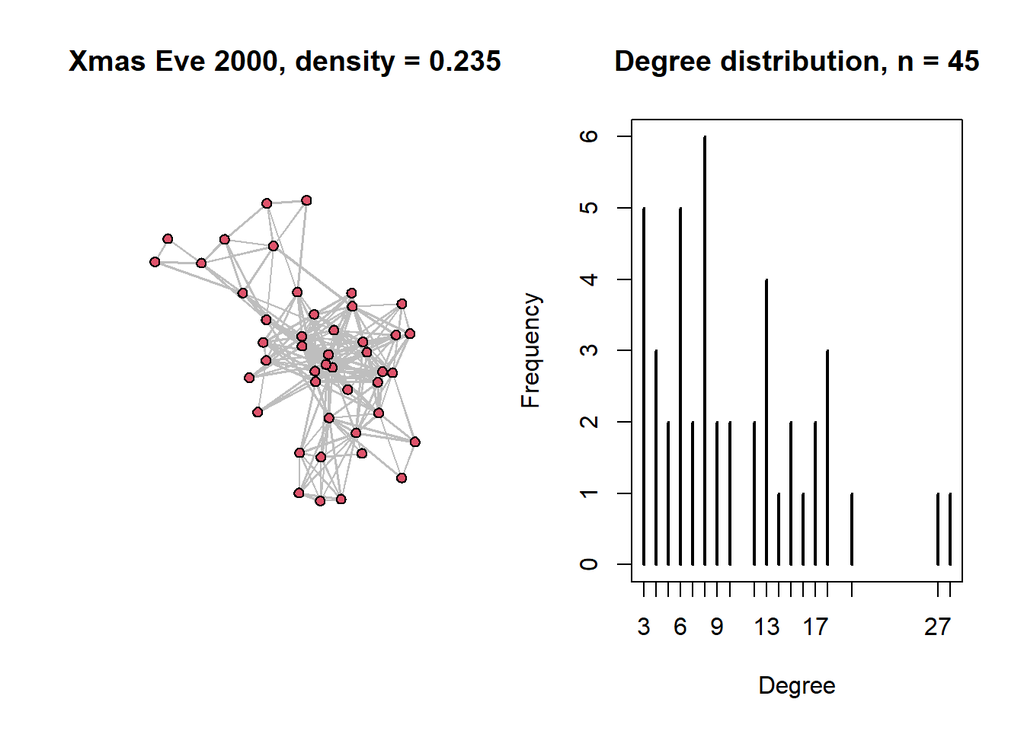

```
## Call:
## ergm(formula = chosenModel, control = control.ergm(MCMC.burnin = 20000,
##     MCMC.interval = 20000))
##
##  Results:
##
##                               Estimate Std. Error MCMC % z value Pr(>|z|)
## edges                          -2.9346     1.8941      0  -1.549    0.121
## altkstar.2                     -2.1647     0.4806      0  -4.504   <1e-04 ***
## gwesp.fixed.0.693147180559945   4.6966     0.4146      0  11.328   <1e-04 ***
## ---
## Signif. codes:  0 '***' 0.001 '**' 0.01 '*' 0.05 '.' 0.1 ' ' 1
##
##      Null Deviance: 1372.4  on 990  degrees of freedom
##  Residual Deviance:  809.8  on 987  degrees of freedom
##
## AIC: 815.8  BIC: 830.5  (Smaller is better. MC Std. Err. = NA)
## [1] "Check if Aus Embassy 2004 is undirected: TRUE"
## [1] "Density for Aus Embassy 2004 : 0.319088319088319"
```

[figure not shown]

```
## Call:
## ergm(formula = chosenModel, control = control.ergm(init = chosenInit,
##     MCMC.burnin = 20000, MCMC.interval = 20000))
##
##  Results:
##
##                               Estimate Std. Error MCMC % z value Pr(>|z|)
## edges                          -1.7506     2.6134      0  -0.670 0.502935
## altkstar.2                     -2.0996     0.6354      0  -3.305 0.000951 ***
## gwesp.fixed.0.693147180559945   4.0521     0.4835      0   8.380  < 1e-04 ***
## ---
## Signif. codes:  0 '***' 0.001 '**' 0.01 '*' 0.05 '.' 0.1 ' ' 1
##
##      Null Deviance: 486.6  on 351  degrees of freedom
##  Residual Deviance: 334.4  on 348  degrees of freedom
##
## AIC: 340.4  BIC: 352  (Smaller is better. MC Std. Err. = NA)
## [1] "Check if Bali 2002 is undirected: TRUE"
## [1] "Density for Bali 2002 : 0.444444444444444"
```

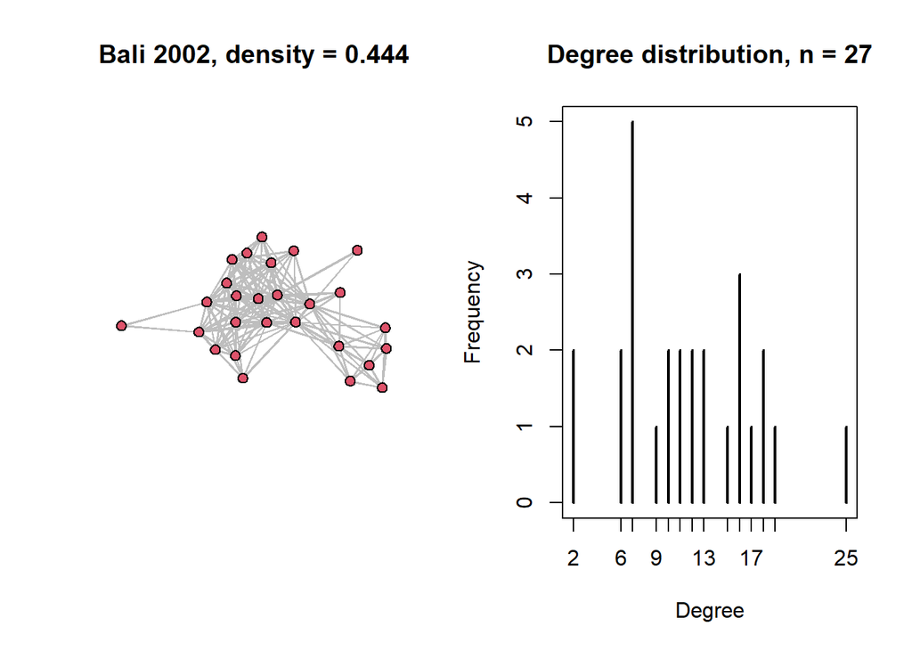

```
## Call:
## ergm(formula = chosenModel, control = control.ergm(init = chosenInit,
##     MCMC.burnin = 20000, MCMC.interval = 20000))
##
##  Results:
##
##                               Estimate Std. Error MCMC % z value Pr(>|z|)
## edges                         -14.6097     3.3953      9  -4.303   <1e-04 ***
## altkstar.2                     -1.7190     0.7996     10  -2.150   0.0316 *
## gwesp.fixed.0.693147180559945   9.7026     1.3793      0   7.035   <1e-04 ***
## ---
## Signif. codes:  0 '***' 0.001 '**' 0.01 '*' 0.05 '.' 0.1 ' ' 1
##
##      Null Deviance: 486.6  on 351  degrees of freedom
##  Residual Deviance: 392.8  on 348  degrees of freedom
##
## AIC: 398.8  BIC: 410.3  (Smaller is better. MC Std. Err. = NA)
## [1] "Check if Bali 2005 is undirected: TRUE"
## [1] "Density for Bali 2005 : 0.256410256410256"
```

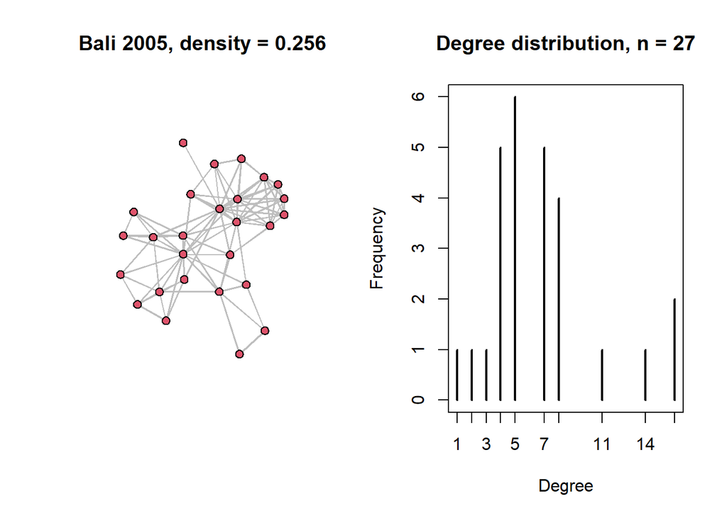

```
## Call:
## ergm(formula = chosenModel, control = control.ergm(init = chosenInit,
##     MCMC.burnin = 20000, MCMC.interval = 20000))
##
##  Results:
##
##                               Estimate Std. Error MCMC % z value Pr(>|z|)
## edges                          -0.7729     1.7786      0  -0.435    0.664
## altkstar.2                     -1.8808     0.4380      0  -4.294   <1e-04 ***
## gwesp.fixed.0.693147180559945   3.1026     0.3672      0   8.450   <1e-04 ***
## ---
## Signif. codes:  0 '***' 0.001 '**' 0.01 '*' 0.05 '.' 0.1 ' ' 1
##
##      Null Deviance: 486.6  on 351  degrees of freedom
##  Residual Deviance: 294.3  on 348  degrees of freedom
##
## AIC: 300.3  BIC: 311.9  (Smaller is better. MC Std. Err. = NA)
## [1] "Check if Hamburg Cell 2001 is undirected: TRUE"
## [1] "Density for Hamburg Cell 2001 : 0.0962566844919786"
```

[figure not shown]

```
## Call:
## ergm(formula = chosenModel, control = control.ergm(init = chosenInit,
##     MCMC.burnin = 20000, MCMC.interval = 20000))
##
##  Results:
##
##                               Estimate Std. Error MCMC % z value Pr(>|z|)
## edges                          -4.0564     0.3657      0 -11.092   <1e-04 ***
## altkstar.2                     -0.1408     0.2261      0  -0.623    0.534
## gwesp.fixed.0.693147180559945   1.4859     0.3304      0   4.497   <1e-04 ***
## ---
## Signif. codes:  0 '***' 0.001 '**' 0.01 '*' 0.05 '.' 0.1 ' ' 1
##
##      Null Deviance: 777.7  on 561  degrees of freedom
##  Residual Deviance: 269.7  on 558  degrees of freedom
##
## AIC: 275.7  BIC: 288.7  (Smaller is better. MC Std. Err. = NA)
## [1] "Check if London Gangs is undirected: TRUE"
## [1] "Density for London Gangs : 0.092941998602376"
```

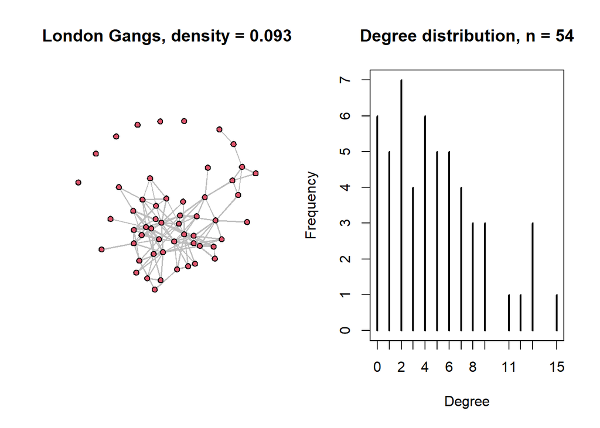

```
## Call:
## ergm(formula = chosenModel, control = control.ergm(MCMC.burnin = 20000,
##     MCMC.interval = 20000))
##
## Monte Carlo Maximum Likelihood Results:
##
##                                Estimate Std. Error MCMC % z value Pr(>|z|)
## edges                         -6.311074   1.019087      0  -6.193  < 1e-04 ***
## altkstar.2                    -0.508678   0.233478      0  -2.179 0.029354 *
## gwesp.fixed.0.693147180559945  1.291148   0.184849      0   6.985  < 1e-04 ***
## nodecov.Age                    0.083793   0.020939      0   4.002  < 1e-04 ***
## absdiff.Age                   -0.176559   0.044867      0  -3.935  < 1e-04 ***
## nodecov.Arrests                0.065577   0.018588      0   3.528 0.000419 ***
## absdiff.Arrests               -0.009927   0.022826      0  -0.435 0.663638
## nodecov.Convictions           -0.080136   0.031164      0  -2.571 0.010126 *
## absdiff.Convictions           -0.073192   0.042208      0  -1.734 0.082902 .
## nodematch.Prison               0.105244   0.185662      0   0.567 0.570811
## nodematch.Birthplace           0.835305   0.154055      0   5.422  < 1e-04 ***
## ---
## Signif. codes:  0 '***' 0.001 '**' 0.01 '*' 0.05 '.' 0.1 ' ' 1
##
##      Null Deviance: 1983.8  on 1431  degrees of freedom
##  Residual Deviance:  667.8  on 1420  degrees of freedom
##
## AIC: 689.8  BIC: 747.8  (Smaller is better. MC Std. Err. = 0.4268)
```

```r
## list of results files to be read in
resultsFiles = list.files(path = here("Output", "20230726_missNetsTrueModels"))




## checking density, degree dist, and what the network looks like
# looping across all the networks
for(netInd in 1:length(adjMatList)){

  ## specify the chosen network
  loopNetwork = adjMatList[[netInd]]

  # grab sample size
  n = nrow(loopNetwork)

  ## check if symmetric

  # symmetrising column and row names because isSymmetric checks this
  colnames(loopNetwork) = rownames(loopNetwork)

  # making sure it's an undirected network
  print(paste("Check if", networkLabels[[netInd]], "is undirected:", isSymmetric(loopNetwork)))

  ## Check density
  # calculating density
  netDensity = (sum(loopNetwork)/2)/((n*(n-1))/2)

  # and a check
  print(paste("Density for ", networkLabels[[netInd]] , " : ", netDensity, sep = ""))

  ## Plotting
  par(mfrow = c(1,2))

  # plot network
  gplot(loopNetwork,
        gmode = "graph",
        edge.col = "grey",
       # vertex.cex = sna::degree(greeceBombs)*0.2,
        main = paste(networkLabels[[netInd]], ",", " density = ", round(netDensity, 3), sep = ""))

  # check degree distribution
  plot(table(colSums(loopNetwork)), type = "h",
       main = paste("Degree distribution, n =", n),
       xlab = "Degree",
       ylab = "Frequency")



  # load in and print model results
  load(here("Output", "20230726_missNetsTrueModels", resultsFiles[[netInd]]))

  # and summarise model
  print(summary(modelres))

}
```

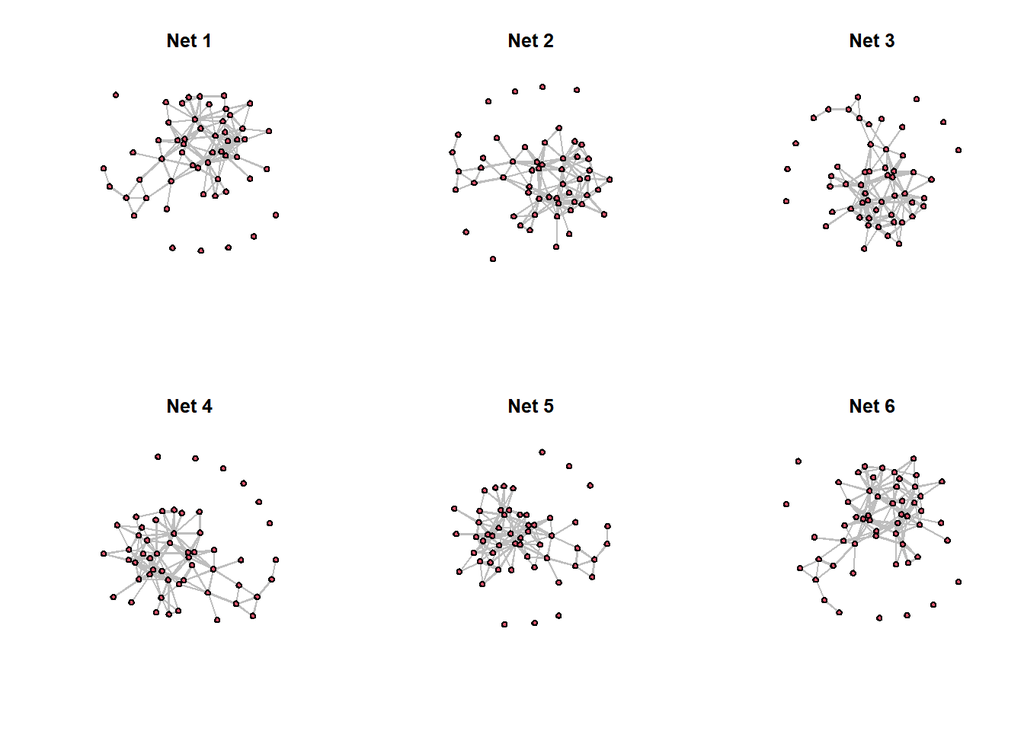

```r
par(mfrow = c(2, 3))

for(netInd in 1:length(adjMatList)){

  ## Additional plot for ASNAC presentation
  gplot(loopNetwork,
        gmode = "graph",
        edge.col = "grey",
        main = paste("Net ", netInd , sep = ""))

}
```

## Missingness simulations

### Independent missingness

```r
## taking some old code

# degrade net function from previous script
## as of August 2023, ignore this for the conditional uniform density model that lets me get a specific proportion of missingness
indepMiss <- function(adjMat, propMiss, directed = FALSE){

  ## indepMiss(adjMat, propMiss, directed) takes a graph and replaces the observed graph ties with missing
  ## values(NA). This function does not handle actor non-response as it only works off the observed
  ## network ties. Works with undirected networks.
  ##
  ## Input:
  ## - adjMat:    An adjacency matrix describing a graph. There shouldn't
  ##             be any missing values in this adjacency matrix yet.
  ##             Should still work if there were though. I think.
  ## - propMiss: A numeric value to indicate the proportion of missingness
  ##             that will be imposed on the observed network.
  ##             Is bounded between 0 and 1.
  ## - directed: A logical value to indicate if it's a directed or
  ##             undirected network. Default is set to undirected.
  ##
  ## Output:
  ## - A degraded network with missing ties where observed ties once were.
  ##   Note that it only handles item non-response for now. Given the inputs,
  ##   the missing values would be ~'propMiss'% of the observed tie variables in 'graph'.

  ## spit out an error if the directed argument is misspecified
  if(directed != TRUE & !isSymmetric(adjMat)){
    stop("The undirected network doesn't have a symmetric matrix")
  }

  ## spit out an error if the proportion of missingness exceeds bounds
  if(propMiss > 1 | propMiss < 0){
    stop("The proportion of missingness exceeds bounds")
  }

  # grab the number of nodes
  n = nrow(adjMat)

  # make an n x n matrix containing randomly generated values between 0 and 1
  missThresh = matrix(data = runif(n^2, min = 0, max = 1),
                      nrow = n,
                      ncol = n)

  # set diagonal to 0 for the dircted network
  diag(missThresh) = 0

  # branch for undirected network
  if( directed == FALSE ){

    # make a matrix
    missThresh = matrix(data = 0, nrow = n, ncol = n)

    # take only one triangle
    missThresh[upper.tri(missThresh)] = runif((n*(n-1))/2)

    # and symmetrise
    missThresh[lower.tri(missThresh)] = t(missThresh)[lower.tri(missThresh)]
  }

  # index which of the ties are going to be missing
  missTies = missThresh <= propMiss

  # copy the graph to punch holes in it
  degradedGraph = adjMat

  # punch holes
  degradedGraph[missTies] = NA

  # diagonal is always fixed to 0, this is an artefact of the way missingness is generated
  diag(degradedGraph) = 0

  # return the degraded graph
  return(degradedGraph)
}


# ## Test run of the function above
# indepMissTrial = indepMiss(adjMat = greeceBombs, propMiss = 0.3, directed = FALSE)
#
# # grabbing the D matrix
# indepMissMat = 1 * is.na(indepMissTrial)

## Seems good enough
```

### Dependencies assumed through an ERGM

```r
# probably needs to be split into a few sections
# one to prep some chosen parameters...
# fix density through the ergm then specify a model

## stuff in the input
# the true network
# a proportion of missingness
# the model for the missingness

## the 'true' network
trueNet = adjMatList[[1]]


## Specify a proportion of missingness
propMiss = 0.3

## this specification was chosen for a couple of reasons:
# a) social circuit assumptions are difficult to justify substantively for missingness
#    but if the point I want to make is that 'dependency maters for missingness', they will suffice
#    because markov model parameters are known to be difficult to work with
# b) dyadCov for the true network (an entrainment effect) to weigh the probability of missingness
#    on the presence of a tie in the true network (either positive or negative weights can be justiied)
# c) a node covariate for degree to weigh more or less popular ties with an additional weight

# For a specific proportion of missing data in the *undirected* network, initialise a random network
# might make this its own helper function.
# this needs to be pretty close to the specified propMiss, so a range of acceptance
# the example below is +/- 1%, set this as a default (for no reason) but allow changes.
acceptRange = 0.01

n = nrow(trueNet)
initMissAdj = matrix(data = 0, nrow = n, ncol = n)

# use only one triangle
initMissAdj[upper.tri(initMissAdj)] = runif(n = (n*(n-1))/2, min = 0, max = 1)

# symmetrise
initMissAdj[lower.tri(initMissAdj)] = t(initMissAdj)[lower.tri(initMissAdj)]

# binarise
initMissAdj = 1*(initMissAdj <= propMiss)

# set diagonal to 0 since it's an artefact of how I've binarised the indicators
diag(initMissAdj) = 0

# check if the density is within the specified acceptable range
initMissDensity = sum(initMissAdj[upper.tri(initMissAdj)]/((n*(n-1))/2))
withinTolerance = with(initMissDensity, initMissDensity < (propMiss + acceptRange) & initMissDensity > (propMiss - acceptRange))

# if values are not within tolerance,
while(!withinTolerance){

  # remake and resample the matrix
  initMissAdj = matrix(data = 0, nrow = n, ncol = n)
  initMissAdj[upper.tri(initMissAdj)] = runif(n = (n*(n-1))/2, min = 0, max = 1)

  # symmetrise
  initMissAdj[lower.tri(initMissAdj)] = t(initMissAdj)[lower.tri(initMissAdj)]

  # binarise
  initMissAdj = 1*(initMissAdj <= propMiss)

  # set diagonal to 0 since it's an artefact of how I've binarised the indicators
  diag(initMissAdj) = 0

  # get the density
  initMissDensity = sum(initMissAdj[upper.tri(initMissAdj)]/((n*(n-1))/2))

  # check if the density is within the specified acceptable range
  withinTolerance = with(initMissDensity, initMissDensity < (propMiss + acceptRange) & initMissDensity > (propMiss - acceptRange))
}

# turn into a network object
initMissNet = network::as.network(initMissAdj, directed = FALSE)
initMissNet %v% 'degree' = rowSums(trueNet)

## specify a model for the missingness
chosenModel =
  initMissNet ~ edges +
  gwdegree(log(2), fixed = TRUE) +
  gwesp(log(2), fixed = TRUE) +
  dyadcov(trueNet) +
  nodecov('degree')

# generate simulated networks
simMissNetStats <- simulate(object = chosenModel, #put in the model object ,
                        # coef = hmm,  # do I need these....
                        nsim = 1000 ,
                        control=control.simulate.formula(MCMC.burnin=1024,MCMC.interval=1024), # a burnin to prepare the importance sampler
                        output='stats',
                        constraints = ~edges)   # this constraint fixes the 'density' (i.e., number of missing tie vars)
```

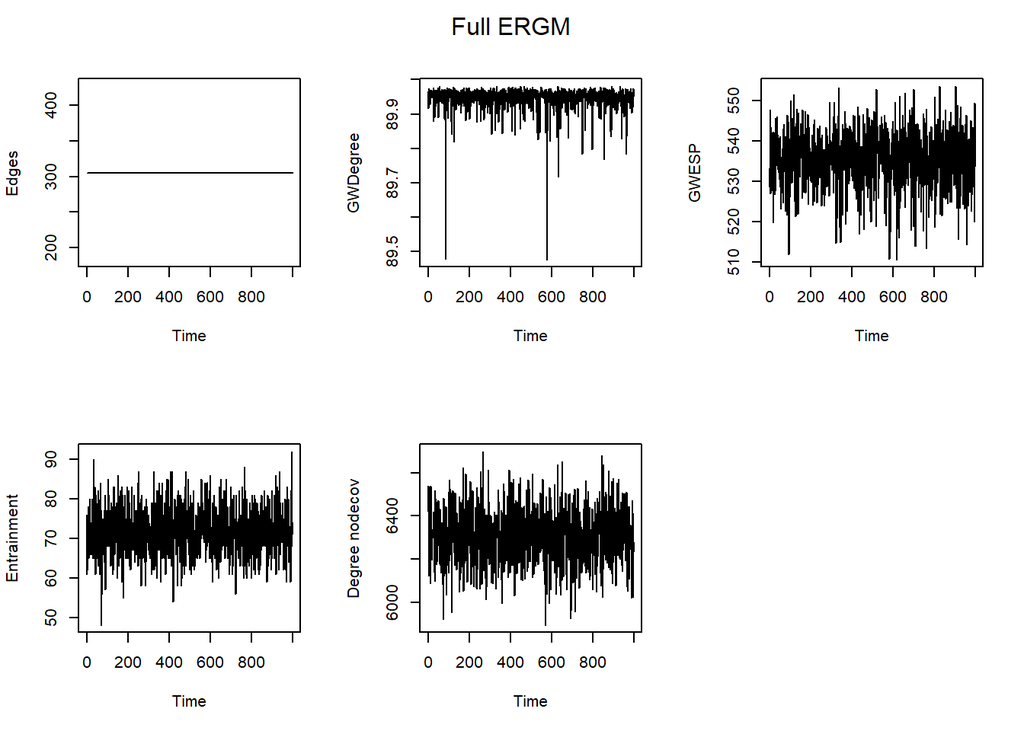

```r
# ideally, the constraint serves to specify the proportion of missingness and make it easier for the model

### What if I wanted a certain specific parameter value... (e.g., positive entrainment or negative GWDegree...?)

# trace plots to see how the parameter values are doing
par(mfrow = c(2,3))
plot(ts(simMissNetStats[,"edges"]), ylab = "Edges")
plot(ts(simMissNetStats[,2]), ylab = "GWDegree")
plot(ts(simMissNetStats[,3]), ylab = "GWESP")
plot(ts(simMissNetStats[,"dyadcov.trueNet"]), ylab = "Entrainment")
plot(ts(simMissNetStats[,"nodecov.degree"]), ylab = "Degree nodecov")

mtext("Full ERGM",
      side = 3,
      line = -2,
      outer = TRUE)
```

### Latent space models

#### Defining the latent space

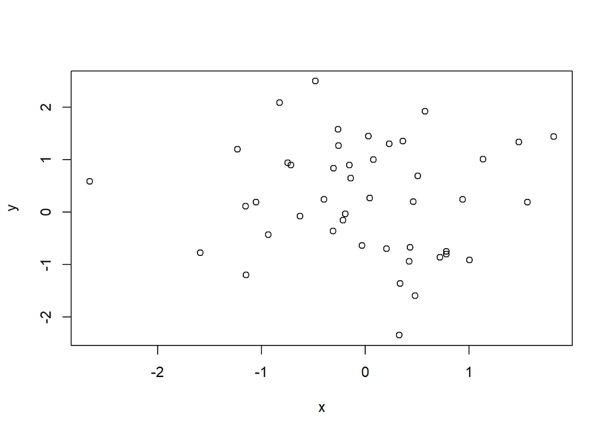

```r
# making an n x k matrix for coordinates
noDim = 2
latentCoords = matrix(0, nrow = n, ncol = noDim)
colnames(latentCoords) = c("x", "y")

# randomly generating positions with a normal dist
for(dim in 1:noDim){
  latentCoords[,dim] = rnorm(n, mean = 0, sd = 1)
}

# viewing the latent space
plot(latentCoords[,1], latentCoords[,2], xlab = "x", ylab = "y")
```

```r
# computing matrix of (Euclidean) distances
distanceMat = matrix(0, nrow = n, ncol = n)

# since there's a subtraction, I don't know how to make this a matrix operation...
for(i in 1:n){
    for(j in 1:n){

    # compute its (Euclidean) distance with every other row
    distanceMat[i,j] = sqrt(sum((latentCoords[i,] - latentCoords[j,])^2))

    }
}

# the distance matrix can be used in a model as a weight for edge formation
```

While (Euclidean) distance between the nodes in the latent space was used for this case, it could be any function of the node coordinates in the latent space.

#### Using the latent space

Taken from Hoff et al. (2002),

$$\eta_{ij} = logodds(x_{ij} = 1 | z_i,
z_j, c_{ij}, \alpha, \beta) = \alpha + \beta'c_{ij} - |z_i -
z_j|,$$

For my particular case, I won’t be using covariates even though they can certainly help. More importantly, I will also be using missingness matrix $\mathbf{D}$,

where
$$D = \begin{cases} 1 \ \text{if
edge } \{i,j\} \notin E \\ 0 \ \text{if edge } \{i,j\} \in E
\end{cases},$$

for edge set $E$. It basically says that $\mathbf{D} = 0$ when the edge is observed and $1$ if it isn’t sampled (i.e., not observed/is missing).

Instead, I am going to be weighing the distance matrix with some model parameter $\beta$,

$$\eta_{ij} = logodds(d_{ij} = 1| z_i,
z_j, \alpha, \beta)) = \alpha + \beta'|z_i - z_j|$$

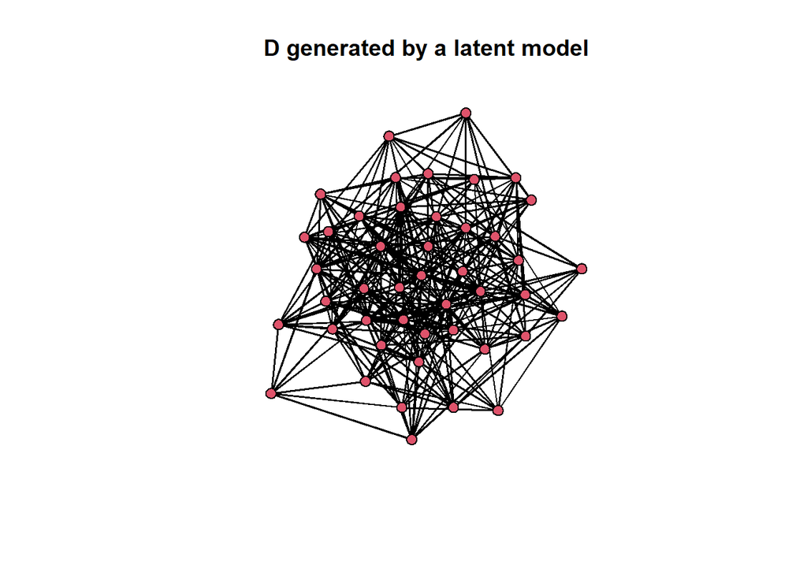

```r
# using the latent space
# in a similar fashion to logistic regression

# specify a proportion of missingness
propMiss = 0.3

# upper bound of log odds basically to make sure density is within range..
logUpperBound = log(propMiss/(1-propMiss))

# the example below is +/- 1%, set this as a default (for no reason) but allow changes.
acceptRange = 0.01

### setting beta value
## weight to describe how much the (Euclidean) distance between nodes affect the observability of the data
# a positive weight indicates that higher (Euclidean) distance makes it more likely for the tie variable to be missing
# a negative weight indicates that higher (Euclidean) distance makes it less likely for the tie variable to be missing

# arbitrarily choosing some random beta value
beta = 0.4

## note: this would be prespecified in the function as a measure of how much the distance matrix affects the eventual missing tie variable probability in the simulation, but can basically be adjusted to fit a proportion of missingness (e.g., sample beta from a prespecified range to fit the propMiss better)
# but it might just be better to fix this and make the intercept do most of the heavylifting for specifying the 'density' of D.

weightedDistMat = beta * distanceMat

### setting base alpha value
## ideally as a function of the propMiss and beta
# my first soln for this is to take the upper bound of the log odds (i.e., corresponding to the specified proportion of missingness)
# and then subtracting it with the average weighted distance (i.e., beta-scaled distance matrix)
# therefore on average the eventual log odds should be equal to the specified proportion of missingness

alpha = logUpperBound - mean(weightedDistMat[upper.tri(weightedDistMat)])

# getting the matrix of etas (probabillity of certain tie variables being missing)
logOddsEta = alpha + weightedDistMat

# transform the log odds to probability values
probEta = apply(logOddsEta, MARGIN = c(1,2), FUN = function(x){exp(x)/(exp(x) + 1)})

# diagonal will always be 0 because adjmat
diag(probEta) = 0

## simulate from these probability values
latentMissMat = apply(probEta, MARGIN = c(1,2), FUN = function(prob){sample(x = c(0,1), size = 1, prob = c(1-prob, prob))})

# since I'm only working with undirected edges,
# symmetrise
latentMissMat[lower.tri(latentMissMat)] = t(latentMissMat)[lower.tri(latentMissMat)]

## a while loop with a unit test so that the density of the network is within acceptable range
# using the 'density' of D to make sure it's close to the propMiss specified
# number of nodes
n = nrow(latentMissMat)

# get the density
missLatentDensity = sum(latentMissMat[upper.tri(latentMissMat)]/((n*(n-1))/2))

# check if the density is within the specified acceptable range
withinTolerance = with(missLatentDensity, missLatentDensity < (propMiss + acceptRange) & missLatentDensity > (propMiss - acceptRange))

# if values are not within tolerance,
while(!withinTolerance){

  # resample the realised matrix
  latentMissMat = apply(probEta, MARGIN = c(1,2), FUN = function(prob){sample(x = c(0,1), size = 1, prob = c(1-prob, prob))})

  # only undirected so far
  # symmetrise
  latentMissMat[lower.tri(latentMissMat)] = t(latentMissMat)[lower.tri(latentMissMat)]

  # get the density
  missLatentDensity = sum(latentMissMat[upper.tri(latentMissMat)]/((n*(n-1))/2))

  # check if the density is within the specified acceptable range
  withinTolerance = with(missLatentDensity, missLatentDensity < (propMiss + acceptRange) & missLatentDensity > (propMiss - acceptRange))
}

# this loop should go (or even not start) until the density is within tolerated values

# I'll use unit testing some day... This stops the code, which doesn't make it ideal for probabilistic elements
# ha = test_that(desc = 'simulated missingness equals expected missingness', code =
#             expect_equal(object = missLatentDensity, expected = propMiss, tolerance = acceptRange))

### is there a diagnostic I can use...?
### or some plot...?
gplot(latentMissMat, gmode = "undirected", main = "D generated by a latent model", usearrows = FALSE)
```

```r
#### to be specified for the functional form
## input
# distance matrix
# propMiss
# acceptable tolerance for density (of the simulated missingness)
# beta value

## output
# a realised matrix for D via the spceified latent coordinates (from a separate function before this)
```

## Other ways to do things (v2 basically)

### Conditionally uniform density

Available through the sna package.

```r
# assume the sna package is read in
initMissAdj = sna::rgnm(n = 1,
                        nv = n,
                        m = round(propMiss*((n*(n-1))/2)),
                        mode = 'graph')

# this gives me a good way to initialise random graphs with a fixed density
```

### Simulating the latent model through statnet

Since the latent model is basically a form of logistic regression with the Euclidean distance matrix (or any other tie-formation function of the latent space coordinates) as an independent covariate. This is also equivalent to an ERGM with a density parameter and a dyadic covariate for the distance (or whatever) matrix. Simulating this with a constraint through the ERGM simulate function will let me generate missingness matrices (D) with a fixed ‘density’.

Because of the constraint in the ERGM, the edges parameter for the simulated ergm can be kept at 0 and I can freely specify the beta value for the weight of the distance (or whatever) matrix.

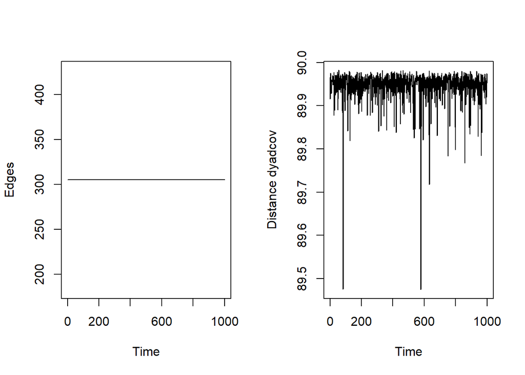

```r
# Another latent model simulation
# now conditionally with a fixed 'density'
latentMissModel = initMissNet ~ dyadcov(distanceMat)

# turn into a network object
initMissNet = network::as.network(initMissAdj, directed = FALSE)

# generate simulated networks
simMissLatentStats <- simulate(object = latentMissModel, #put in the model object ,
                        coef = beta,  # do I need these....
                        nsim = 1000 ,
                        control=control.simulate.formula(MCMC.burnin=1024,MCMC.interval=1024), # a burnin to prepare the importance sampler
                        output='stats',
                        constraints = ~edges)   # this constraint fixes the 'density' (i.e., number of missing tie vars)

# check trace plots
par(mfrow = c(1, 2))
plot(ts(simMissNetStats[,"edges"]), ylab = "Edges")
plot(ts(simMissNetStats[,2]), ylab = "Distance dyadcov")
```

## Functional forms

Everything above is figuring out what code is necessary to be put into a function. The parts below turn them into functions that are hopefully easy to figure out and documented well.

My own tips for readable code:

1. comments. I find myself in the opposite end of the spectrum and have a tendency for over-commenting. KEEP IT SHORT
2. object names. I tend to stick to camelCase.. With abbreviations, I tend to keep them capitalised, but I just looked up how camelCase handles abbreviations and they’re agnostic to any additional considerations (e.g., missErgmBayes > missERGMBayes for readability)
3. Functions. These are going to be made… so yep. Keep them small. Make it modular and split them up when necessary. Fewer arguments and more focused functions the better.
4. Indentation and readbility. yes. Indents. PLEASE.
5. Unit test when necessary or appropriate.
6. Follow Jenny Bryan’s code smells for bad habits.

### Dependency through specified ERGMs

```r
## function to initialise missingness matrix
initMissAdj = function(n, propMiss, numSims = 1, mode = "graph", ...){


  ## initMissAdj(n, propMiss, numSims, ...) takes a number of nodes, a proportion of missingness,
  ## a number of simulated networks, and any additional arguments supported by sna::rgnm() to
  ## generate a uniform network conditioned on the density of the graph.
  ##
  ## Input:
  ## - n:        An integer for the number of nodes for the missingness indicator matrix.
  ##
  ## - propMiss: A numeric value to indicate the proportion of missingness to calculate
  ##             the 'density' of the missingness matrix
  ##             Is bounded between 0 and 1.
  ##
  ## - numSims:  An integer for the number of simulated networks to be generated.
  ##             The default is set to 1 for the function to return a matrix,
  ##             If set to be above one, it will return a numSims x n x n array.
  ##
  ## - mode:     A string to be used for the sna::rgnm() for the type of graph to be generated.
  ##             Default is set to 'graph' for an undirected graph. Can be changed to 'digraph'.
  ##             For directed graphs.
  ##
  ## Output:
  ## - An n x n matrix (or numSims x n x n array) containing a completely uniform (Bernoulli) graph
  ##   with an exact density (propMiss). Can also be used for independent missingness.

  # needs the sna package
  require(sna)

  # assume the sna package is read in
  initAdj = sna::rgnm(n = numSims,                       # number of simulated networks
                      nv = n,                            # number of nodes
                      m = round(propMiss*((n*(n-1))/2)), # number of dyads (for density)
                      mode = mode)                       # type of graph

  # return the simulated object
  return(initAdj)
}



### simulation function

simMissNet = function(model, coef){

  ## simMissNet(model, coef) takes a model and a set of coefficients for the model
  ## and plugs it in the simulate.ergm() function to return 1000 (can be modified..) networks
  ## with fixed density (constrained number of edges).
  ##
  ## Input:
  ## - model: A statnet model object. The outcome has to be a network object, the
  ##          predictors need to be ergm.terms.
  ##
  ## - coef:  A vector of coefficients needed to simulate the networks on. These
  ##          should be chosen corresponding to the local endogenous assumptions made
  ##          about the missingness
  ##
  ## Output:
  ## - A list of 1000 (modifiable...) networks simulated with the specified model.

  # needs ergm or wouldn't work
  require(ergm)

  # generate the simulated networks
  simMissNets <- simulate(object = model, # put in the model object ,
                          coef = coef,  # I *do* need these. edges can be set to 0 when the constraint is in
                          nsim = 1000,
                          control = control.simulate.formula(MCMC.burnin=20000,MCMC.interval=100), # a burnin to prepare the importance sampler
                          constraints = ~edges)   # this constraint fixes the 'density' (i.e., number of missing tie vars)

  # return the simulated networks
  return(simMissNets)
}





### Diagnostic function basically
missSimDiag = function(simObj, modelName = "Full ERGM"){

  ## missSimDiag(simObj, modelName) takes a simulated matrix of network statistics from
  ## the simulate.ergm() function and plots the trace plots of the parameters.
  ##
  ## Input:
  ## - simObj: A matrix object containing the simulated networks from
  ##           the output of a simulate.ergm() function.
  ##
  ## - modelName:   A string to indicate the name of the model that is simulated.
  ##                Its default is a 'Full ERGM' simulation.
  ##
  ## Output:
  ## - For number of parameters p in the simulated object, p trace plots arranged in
  ##   2 columns.

  # needs ergm
  require(ergm)

  # take out the statistics from the simulated object
  simObjStats = attr(simObj, "stats")

  # number of parameters
  p = ncol(simObjStats)

  # setting margins for the trace plots
  # setting it to 2 columns (arbitrarily)
  # and setting the number of rows to the ceiling of the number of parameters, halved
  par(mfrow = c(ceiling(p/2), 2))

  # for loop to plot each trace plot
  for(ind in 1:ncol(simObjStats)){

    # trace plots to see how the parameter values are doing
    plot(ts(simObjStats[,ind]), ylab = colnames(simObjStats)[ind])
  }

# setting text for the whole plot
mtext(text = modelName,
      side = 3,
      line = -2,
      outer = TRUE)
}
```

### Latent space model for missingness

```r
### Initialising some latent space
simLatentCoords = function(n, noDim = 2){

  ## simLatentCoords(n, noDim) takes a simulated matrix of network statistics from
  ## the simulate.ergm() function and plots the trace plots of the parameters.
  ##
  ## Input:
  ## - n:     An integer for the number of nodes for the missingness indicator matrix.
  ##
  ## - noDim: An integer for the number of dimensions in the latent space. The default is
  ##          set to 2. Upwards of 3 dimensions (4+) might be difficult to visualise.
  ## Output:
  ## - An n x noDim matrix with random standardised normal values for each dimension.

  # specify the matrix of coordinates
  latentCoords = matrix(0, nrow = n, ncol = noDim)

  # using the base constant letters for axis names
  colnames(latentCoords) = letters[1:noDim]

  # randomly generating positions with a normal dist
  for(dim in 1:noDim){
    latentCoords[,dim] = rnorm(n, mean = 0, sd = 1)
  }

  # return the latent coordinates
  return(latentCoords)
}
```

### Degradation function

```r
# A general purpose function to degrade 'true' matrices
degradeAdj = function(trueNet, missAdj, missSave = NA){

  ## degradeAdj(trueNet, missNet, missSave) takes a 'true network' and then degrades
  ## the network with the missingness adjacency matrix provided. The missingness can then
  ## be saved as either missing values (NA) or any other value (e.g., 1).
  ##
  ## Input:
  ## - trueNet:  An n x n adjacency matrix to indicate the 'true' network.
  ##
  ## - missAdj:  An n x n adjacency matrix to indicate the missingness/observation of tie variables
  ##             for the provided true network.
  ##
  ## - missSave: Any value (usually integer or NA) to be used as the value missingness is saved as.
  ##             The default is set to NA for missing as per R definitions, but can be any value.
  ##
  ## Output:
  ## - An n x n matrix containing missing values (however saved/stored) for the provided missingness
  ##   matrix.

  # make sure the object types are right
  test_that(desc = "Make sure both objects are matrices",
            code = expect_true(inherits(trueNet, "matrix") && inherits(missAdj, "matrix")))


  # copy the graph to punch holes in it
  degradedGraph = trueNet

  # punch holes
  degradedGraph[missAdj==1] = missSave

  # return the degraded graph
  return(degradedGraph)

}
```

## What to do with the functions:

(the tutorial for using the functions)

### Setting parameters

```r
## These values will be used for all the functions below so:
# first choosing the dataset
trueNet = adjMatList[[1]]

# setting proportion of missingness
propMiss = 0.3
```

### Indep miss tutorial

```r
## initMissAdj for a bernoulli generated graph with a given density
indepMissAdj = initMissAdj(n = nrow(trueNet),
                           propMiss = propMiss)

# and degrade it
indepDegradedAdj = degradeAdj(trueNet = trueNet,
                              missAdj = indepMissAdj)
```

```
## Test passed 🎉
```

```r
## unit test to make sure the proportions are right
# grab the maximum number of ties for the matrix
n = nrow(trueNet)

# calculate a 'density' of sorts with the NAs in the degraded matrix
# not dividing the density at the end by 2 because the sum is counting both ends of the undirected matrix
test_that(desc = 'Independently simulated missingness equals expected missingness', code =
            expect_equal(object = sum(is.na(indepDegradedAdj))/((n * (n-1))), expected = propMiss))
```

```
## Test passed 🌈
```

### ERGM miss tutorial

```r
## generate the initial missingness matrix
initAdj = initMissAdj(n = nrow(trueNet), propMiss = 0.3)

# turn into a network object
initMissNet = network::as.network(initAdj, directed = FALSE)
initMissNet %v% 'degree' = rowSums(trueNet)

# setting coefficients for the ERGM
someCoefs = c(0, 0.4, 0.5, 0.8, 0.2)  # everything set to positive is dangerous for mcmc explosions, but fixed density helps.

## specify a model for the missingness
# Note: 0.69 is chosen for the decay value because that's what log(2) is. Rounding lets the diagnostic plots be more interpretable

## this specification was chosen for a couple of reasons:
# a) social circuit assumptions are difficult to justify substantively for missingness
#    but if the point I want to make is that 'dependency maters for missingness', they will suffice
#    because markov model parameters are known to be difficult to work with
# b) dyadCov for the true network (an entrainment effect) to weigh the probability of missingness
#    on the presence of a tie in the true network (either positive or negative weights can be justiied)
# c) a node covariate for degree to weigh more or less popular ties with an additional weight,
#    a positive value means that nodes with higher degree are more likely to have missing tie variables
chosenModel =
  initMissNet ~ edges +
  gwdegree(0.69, fixed = TRUE) +
  gwesp(0.69, fixed = TRUE) +
  dyadcov(trueNet) +
  nodecov('degree')

# and now we simulate
missErgmSimNets = simMissNet(model = chosenModel, coef = someCoefs)

# and check diagnostics
missSimDiag(simObj = missErgmSimNets)

# randomly sampling from the simulated random networks
chosenErgmMissInd = sample(1:length(missErgmSimNets), size = 1)
print(paste("Your chosen missingness network for the ERGM-simulated missingness is", chosenErgmMissInd))
```

```
## [1] "Your chosen missingness network for the ERGM-simulated missingness is 95"
```

```r
# take that network out
ergmMissAdj = as.matrix(missErgmSimNets[[chosenErgmMissInd]])

# and degrade
ergmDegradedAdj = degradeAdj(trueNet = trueNet,
                             missAdj = ergmMissAdj)
```

```
## Test passed 🌈
```

```r
# and check that it's degrading properly..
# calculate a 'density' of sorts with the NAs in the degraded matrix
# not dividing the density at the end by 2 because the sum is counting both ends of the undirected matrix
test_that(desc = 'ERGM-simulated missingness equals expected missingness',
          code = expect_equal(object = sum(is.na(ergmDegradedAdj))/((n * (n-1))), expected = propMiss))
```

```
## Test passed 🌈
```

[figure not shown]

### Latent miss tutorial

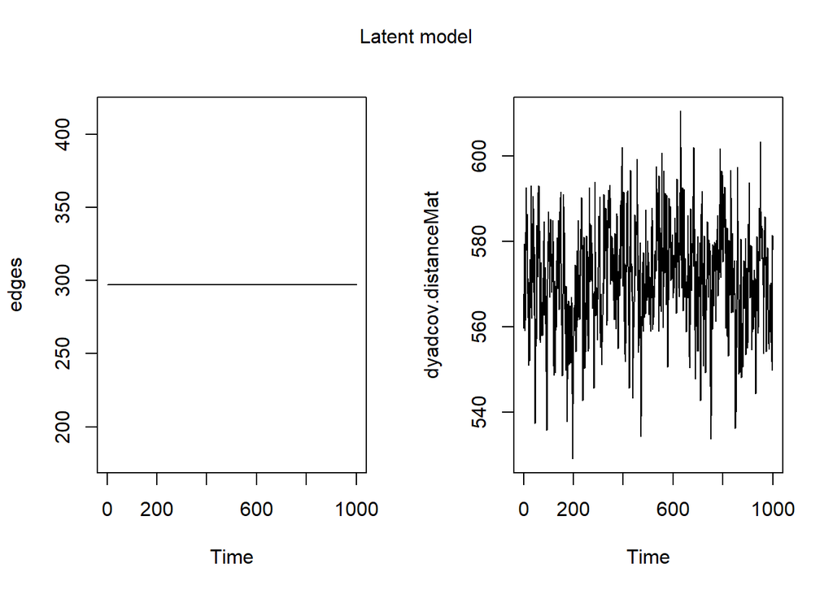

```r
# latent model parameters
# specifying the model with an initialised missingness matrix (with specific 'density')
# with a single covariate being a dyadic covariate for the distance matrix
# edges included for the trace plots' sake
latentMissModel = initMissNet ~ edges + dyadcov(distanceMat)

# setting the coefficient value (the 'beta' value that weighs the distance matrix)
beta = 0.4

# generate latent variable coordinates
latentCoords = simLatentCoords(n = nrow(trueNet),
                               noDim = 2)

# instead of making my own distance function that doesn't support more than 2 dimensions,
# why not make life easier and use stats::dist instead?
distanceMat = as.matrix(stats::dist(latentCoords))

## doing it with the previously specified functions for the ergm simulation
## generate the initial missingness matrix
initAdj = initMissAdj(n = nrow(trueNet), propMiss = 0.3)

# turn initialised missingness matrix into a network object
initMissNet = network::as.network(initAdj, directed = FALSE)

# and then simulate
missLatentSimNets = simMissNet(model = latentMissModel, coef = c(0,beta))

# then can check the same diagnostics as above
missSimDiag(simObj = missLatentSimNets, modelName = "Latent model")
```

```r
# and go through the same process of choosing a network and depleting with it
# randomly sampling from the simulated random networks
chosenLatentMissInd = sample(1:length(missLatentSimNets), size = 1)
print(paste("Your chosen missingness network for the ERGM-simulated missingness is", chosenLatentMissInd))
```

```
## [1] "Your chosen missingness network for the ERGM-simulated missingness is 52"
```

```r
# take that network out
latentMissAdj = as.matrix(missLatentSimNets[[chosenLatentMissInd]])

# and degrade
latentDegradedAdj = degradeAdj(trueNet = trueNet,
                               missAdj = latentMissAdj)
```

```
## Test passed 😸
```

```r
# and check that it's degrading properly..
# calculate a 'density' of sorts with the NAs in the degraded matrix
# not dividing the density at the end by 2 because the sum is counting both ends of the undirected matrix
test_that(desc = 'Latent model simulated missingness equals expected missingness',
          code = expect_equal(object = sum(is.na(latentDegradedAdj))/((n * (n-1))), expected = propMiss))
```

```
## Test passed 🥇
```